# NEON forecasting challenge

rachel torres

2025-01-22

## NEON phenology data viz

[steps to code are from this webste](https://projects.ecoforecast.org/neon4cast-ci/targets.html)

Description of data:

**gcc_90** - P1D - Green chromatic coordinate is the ratio of the green digital number to the sum of the red, green, blue digital numbers from a digital camera.  
Horizon: 30 days  
Latency: ~ 2 days

**rcc_90** - P1D - Red chromatic coordinate is the ratio of the Red digital number to the sum of the red, green, blue digital numbers from a digital camera. Horizon: 30 days  
Latency: ~ 2 days

First, select a site where phenology data is available ([see table](https://projects.ecoforecast.org/neon4cast-ci/targets.html) where phenology is marked 1)

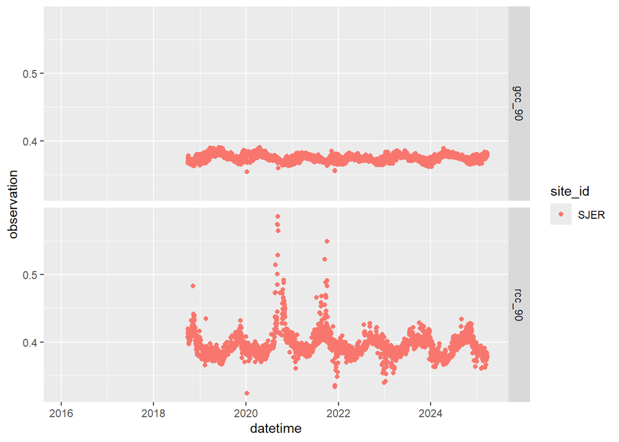

```r
#set download url
url <- "https://sdsc.osn.xsede.org/bio230014-bucket01/challenges/targets/project_id=neon4cast/duration=P1D/phenology-targets.csv.gz"

# get data frame from website
phenology_targets <- read_csv(url, show_col_types = FALSE)

# filter by site id
sites <- phenology_targets %>% filter(site_id=="SJER")

# plot time series
ggplot(sites) +
  geom_point(aes(x=datetime, y=observation, col=site_id)) +
  facet_grid('variable')
```

Other ideas to explore in visualization:

- plots to make to explore - time series
- smooth time series
- monthly averages
- monthly values with year by color
- daily values by year
- average daily values

## Example Plot

[output not shown]

[figure not shown]

```r
# example plot that combines filter, mutating, aggregating

sites %>%
  # filter by site id
  filter(site_id=="ABBY" &
           # filter by variable - only gcc90
           variable=="gcc_90") %>%
  # use lubridate functions to get different time steps
  mutate(month = month(datetime),
         year=year(datetime),
         yd=yday(datetime)) %>%
  # summarize
  group_by(yd, year) %>%
  summarize(gcc90 = mean(observation)) %>%
  # plot
  ggplot(aes(x=yd,
             y=gcc90,
             col=as.factor(year))) +
  geom_line()
```

```r
# to use only 1 site, use the filter function
# saving as new data frame 'site_dates'
site_dates = sites %>% filter(site_id=="SJER")
```

Continue your own code below - what patterns can you find?

## Let’s look at climate data for the NEON site

We are going to load more data using the `neonUtilities` R package - see examples [here](https://www.neonscience.org/resources/learning-hub/tutorials/neondatastackr)

We want to get air temperature values, which are available as 1 and 30 minute average from triple aspirated observations, and have an ID of DP1.00003.001.

See a full list of data products [here](https://data.neonscience.org/data-products/explore)

other IDs you might be interested

- precipitation - DP1.00006.001
- shortwave radiation - DP1.00014.001
- photosynthetically active radiation (PAR) - DP1.00024.001

```r
# run this first to install
#install.packages("neonUtilities")

# load package
library(neonUtilities)

# get the start and end dates for the SJER site
# first get the date column for only SJER
site_dates = sites %>% filter(site_id=="SJER")
# the functions below select the first and last date entry in the datetime column, then format to Year-month
start = format(site_dates$datetime[1], "%Y-%m")
end = format(site_dates$datetime[nrow(site_dates)], "%Y-%m")

# alternatively to above, you could hand select your start and end times, format has to be Year-month
start = "2017-01"
end = "2025-01"

# download the triple aspirated temperature files - for site SJER only to start - check your console, this may take a minute
# to download a different clim variable, change dpID
# triptemp <- loadByProduct(dpID=c("DP1.00003.001"),
#                           site=c("SJER"),
#                           startdate=start,
#                           enddate=end)
# the format of this download is a list of 7 that contains metadata and data frames for 1 minute observations (TAAT_1min) and 30 minute (TAAT_30min)

phen <- loadByProduct(dpID=c("DP1.00003.001"),
                          site=c("SJER"),
                          startdate=start,
                          enddate=end,
                      tabl="TAAT_1min") # use tabl to select the data frame inside the list that comes from neon download

# get daily min, max, and mean temps
minute_daily_avg = phen$TAAT_1min %>%
  mutate(date = date(startDateTime),
         month = month(startDateTime),
         year=year(date)) %>%
  fill(tempTripleMean) %>%
  filter(month==3) %>%
  group_by(year) %>%
  summarize(march_tmin = min(tempTripleMean),
            march_tmax = max(tempTripleMean),
            march_tmean = mean(tempTripleMean))

ggplot(minute_daily_avg,
       aes(x=date, y=tmean)) +
  geom_point() +
  geom_point(aes(x=date, y=tmin, col="tmin")) +
  geom_point(aes(x=date, y=tmax, col="tmax"))

# save dataframe to computer so don't have to download again
saveRDS(minute_daily_avg, "SJER_trip_temp_NEON.Rds")
```

## Get Accumulated growing degree days

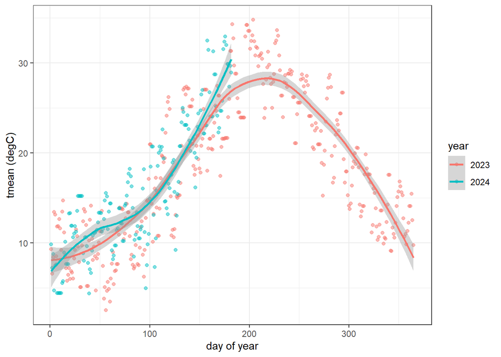

```r
minute_daily_avg <- readRDS("../data/SJER_trip_temp_NEON.Rds")


# calculate gdd as the mean over the threshold (because we are working in celsius, the threshold is 0 or 32F, we only need the mean)

gdd = minute_daily_avg %>%
  mutate(tmean = (tmin+tmax)/2,
         year = year(date),
         doy = yday(date)) %>%
  dplyr::select(year, doy, tmean) %>%
  filter(year>2022) %>%
  fill(tmean) # not the best strategy but will work for now - fills NA values with previous value

# plot as avg temperature (gdd)
ggplot(gdd, aes(x=doy, y=tmean, col=as.factor(year))) +
  geom_point(alpha=0.5) +
  geom_smooth() +
  labs(x="day of year", y="tmean (degC)", col="year") +
  theme_bw()
```

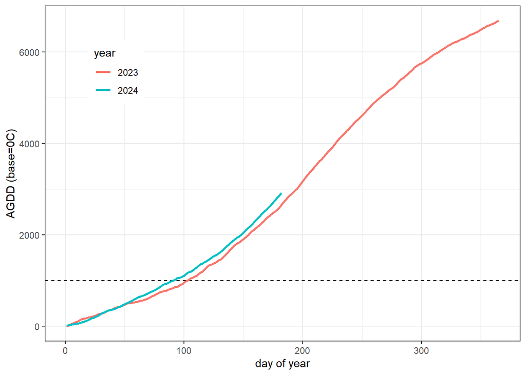

```r
# create a new column for cumulative values, starting at 0 for each year
# cumsum is a base function that takes a vector and produces a new vector with cumulative values. try putting ?cumsum into your console to learn more, or visualize an example by putting `cumsum(c(1,2,3,4))` into your console
gdd <- gdd %>%
  group_by(year) %>%
  mutate(agdd = cumsum(tmean))

# plot agdd
ggplot(gdd, aes(x=doy, y=agdd, col=as.factor(year))) +
  geom_hline(aes(yintercept=1000), linetype="dashed") +
  geom_line(linewidth=1) +
  labs(x="day of year", y="AGDD (base=0C)", col="year") +
  theme_bw() + theme(legend.position = "inside",
                     legend.position.inside = c(0.15, 0.8))
```

## Combine phenology and climate data

Continuing with temperature data, going to create a data frame that includes columns for dates, gcc90, and temperature, then will do example plot

To do this, we will use a join function from the `dplyr` package. Read more [here](https://dplyr.tidyverse.org/reference/mutate-joins.html).

I am continuing to look at the SJER site only, where I downloaded the climate data.

```r
# to join, we need one column to have the same identifier, in this case the date needs to be in the same format and column name

# changing format of date in site_dates to match date in minute_daily_avg
site_dates$date = ymd(site_dates$datetime)

# inner_join maintains all columns and joins by dates
phen_temps = inner_join(site_dates, minute_daily_avg, by="date")

# preview new dataframe
head(phen_temps)
```

```
## # A tibble: 6 × 10
##   project_id site_id datetime            duration variable observation
##   <chr>      <chr>   <dttm>              <chr>    <chr>          <dbl>
## 1 neon4cast  SJER    2018-09-06 00:00:00 P1D      gcc_90            NA
## 2 neon4cast  SJER    2018-09-07 00:00:00 P1D      gcc_90            NA
## 3 neon4cast  SJER    2018-09-08 00:00:00 P1D      gcc_90            NA
## 4 neon4cast  SJER    2018-09-09 00:00:00 P1D      gcc_90            NA
## 5 neon4cast  SJER    2018-09-10 00:00:00 P1D      gcc_90            NA
## 6 neon4cast  SJER    2018-09-11 00:00:00 P1D      gcc_90            NA
## # ℹ 4 more variables: date <date>, tmin <dbl>, tmax <dbl>, tmean <dbl>
```

```r
summary(phen_temps)
```

```
##   project_id          site_id             datetime            duration
##  Length:4250        Length:4250        Min.   :2018-09-06   Length:4250
##  Class :character   Class :character   1st Qu.:2020-02-19   Class :character
##  Mode  :character   Mode  :character   Median :2021-08-03   Mode  :character
##                                        Mean   :2021-08-03
##                                        3rd Qu.:2023-01-16
##                                        Max.   :2024-06-30
##
##    variable          observation          date                 tmin
##  Length:4250        Min.   :0.3237   Min.   :2018-09-06   Min.   :-1.129
##  Class :character   1st Qu.:0.3732   1st Qu.:2020-02-19   1st Qu.: 8.551
##  Mode  :character   Median :0.3792   Median :2021-08-03   Median :13.104
##                     Mean   :0.3841   Mean   :2021-08-03   Mean   :14.517
##                     3rd Qu.:0.3912   3rd Qu.:2023-01-16   3rd Qu.:20.906
##                     Max.   :0.5859   Max.   :2024-06-30   Max.   :31.815
##                     NA's   :120                           NA's   :366
##       tmax           tmean
##  Min.   : 5.01   Min.   : 1.706
##  1st Qu.:15.39   1st Qu.:11.696
##  Median :22.66   Median :17.315
##  Mean   :23.12   Mean   :18.315
##  3rd Qu.:31.21   3rd Qu.:25.493
##  Max.   :42.15   Max.   :36.545
##  NA's   :366     NA's   :366
```

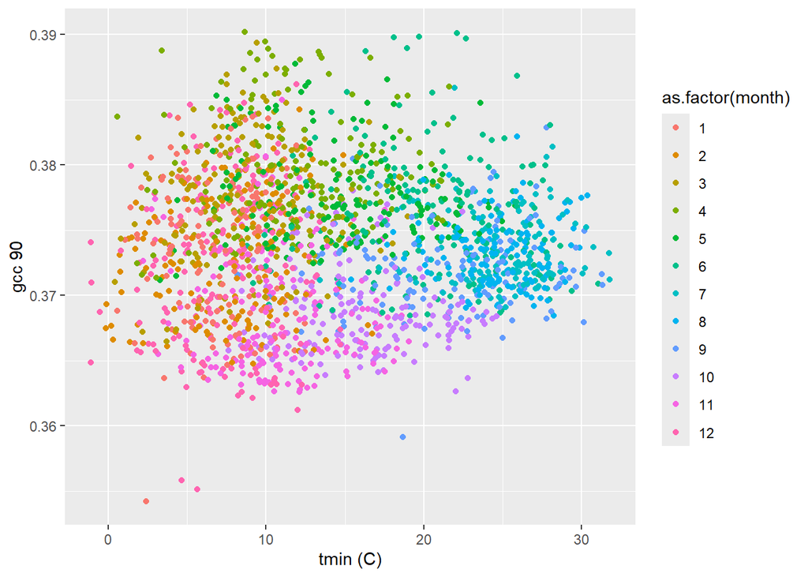

```r
# add other columns for different temporal groupings
phen_temps <- phen_temps %>%
  mutate(year=year(date),
         month=month(date),
         doy=yday(date))

# start thinking about how to plot to explore patterns
phen_temps %>%
  filter(variable=="gcc_90") %>%
  ggplot(aes(x=tmin, y=observation, col=as.factor(month))) + geom_point() +
  labs(x="tmin (C)", y="gcc 90")
```

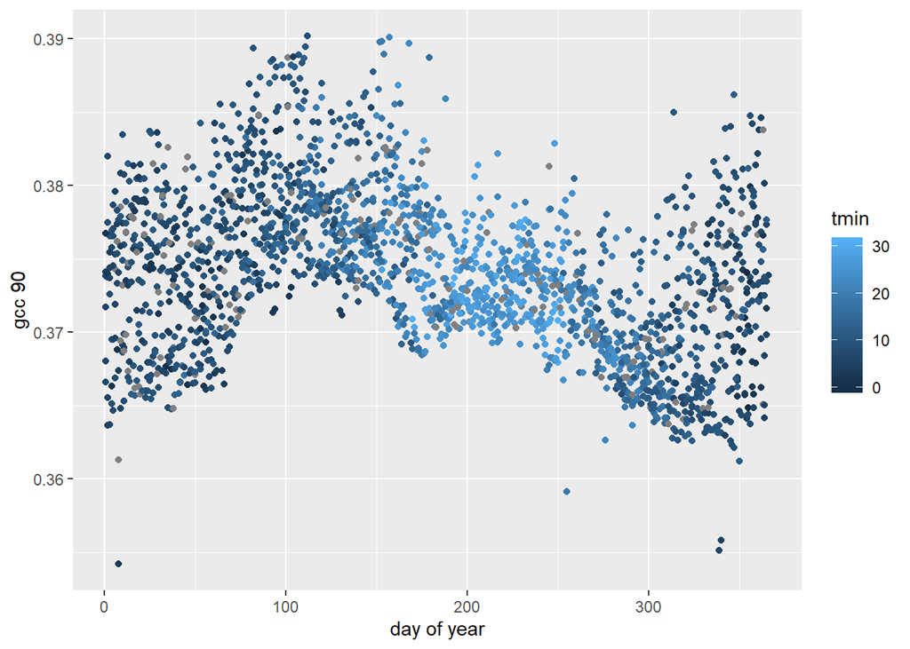

```r
# compare gcc with spring temps
phen_temps %>%
  filter(variable=="gcc_90") %>%
  ggplot(aes(x=doy, y=observation, col=tmin)) + geom_point() +
  labs(x="day of year", y="gcc 90")
```